# master_thesis_data_preparation

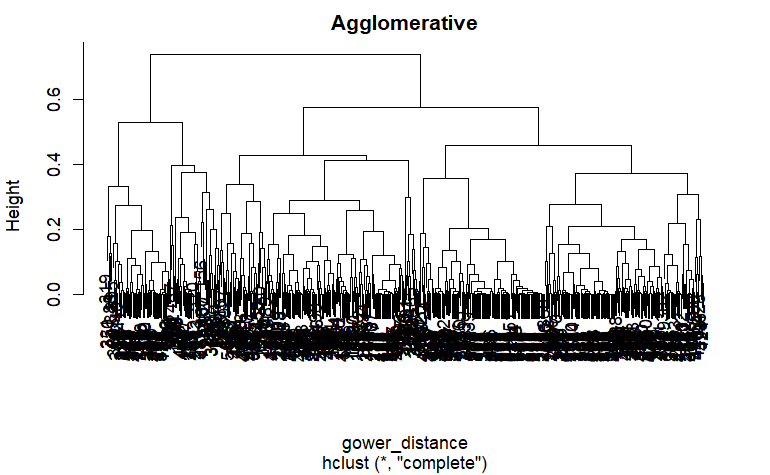

```r
# agglomerative clustering
agglomorative_clustering <- hclust(gower_distance, method = "complete")
plot(agglomorative_clustering, main = "Agglomerative")
```

```r
# library(fpc)
#
# c_stats_table <- function(dist, tree, k){
#   cluster_assess <- c("cluster_number", "n", "within_cluster", "average_within", "average_between", "wb_ratio", "dunn_2", "avg_silwidth")
#   cluster_size <- c("cluster_size")
#   stats_names <- c()
#   row_cluster <- c()
#
#   output_stats <- matrix(ncol = k, nrow = length(cluster_assess))
#   cluster_sizes <- matrix(ncol = k, nrow = k)
#
#   for (i in c(1:k)){
#     row_cluster[i] <- paste("Cluster-", i, " size")
#   }
#
#   for (i in c(2:k)){
#     stats_names[i] <- paste("Test", i - 1)
#
#     for (j in seq_along(cluster_assess)){
#       output_stats[j, i] <- unlist(cluster.stats(d = dist, clustering = cutree(tree, k = i))[cluster_assess])[j]
#     }
#
#     for (d in 1:k){
#       cluster_sizes[d, i] <- unlist(cluster.stats(d = dist, clustering = cutree(tree, k = i))[cluster_size])[d]
#       dim(cluster_sizes[d, i]) <- c(length(cluster_sizes[i]), 1)
#       cluster_sizes[d, i]
#     }
#   }
#
#   output_stats_df <- data.frame(output_stats)
#
#   cluster_sizes <- data.frame(cluster_sizes)
#   cluster_sizes[is.na(cluster_sizes)] <- 0
#
#   rows_all <- c(cluster_assess, row_cluster)
#
#   output <- rbind(output_stats_df, cluster_sizes)[,-1]
#   colnames(output) <- stats_names[2:k]
#   rownames(output) <- rows_all
#
#   is_num <- sapply(output, is.numeric)
#   output[is.num] <- lapply(output[is.num], round, 2)
#
#   output
# }
#
#
#
# stats_df_divisive <- c_stats_table(gower_distance, divisive_clustering, 5)
# stats_df_divisive
```

```r
library(poLCA)

formula_1 <- cbind(gender, education, occupation, av_income_factorized, environment) ~ 1

lca_1 <- poLCA(formula_1, data_cluster, nclass = 3,
               maxiter = 10000)
```

```
Conditional item response (column) probabilities,
 by outcome variable, for each class (row)

$gender
           Pr(1)  Pr(2)  Pr(3)  Pr(4)
class 1:  0.3419 0.6536 0.0000 0.0045
class 2:  0.8897 0.0964 0.0138 0.0000
class 3:  0.6880 0.3062 0.0058 0.0000

$education
           Pr(1)  Pr(2)  Pr(3)  Pr(4)  Pr(5)  Pr(6)  Pr(7)
class 1:  0.0000 0.0019 0.0208 0.2040 0.5974 0.1759 0.0000
class 2:  0.0000 0.1211 0.0548 0.4623 0.3343 0.0000 0.0275
class 3:  0.0059 0.0000 0.2966 0.6094 0.0881 0.0000 0.0000

$occupation
           Pr(1)  Pr(2)  Pr(3)  Pr(4)  Pr(5)  Pr(6)  Pr(7)
class 1:  0.0000 0.0110 0.0134 0.7285 0.1063 0.0096 0.1312
class 2:  0.0073 0.0126 0.0197 0.8279 0.0254 0.0147 0.0924
class 3:  0.0349 0.8099 0.0127 0.0662 0.0103 0.0454 0.0206

$av_income_factorized
           Pr(1)  Pr(2)  Pr(3)  Pr(4)  Pr(5)  Pr(6)
class 1:  0.0000 0.0000 0.1800 0.2839 0.4916 0.0446
class 2:  0.0787 0.2109 0.5761 0.0830 0.0000 0.0513
class 3:  0.5738 0.2786 0.0378 0.0000 0.0000 0.1098

$environment
           Pr(1)  Pr(2)
class 1:  0.8311 0.1689
class 2:  0.8422 0.1578
class 3:  0.7552 0.2448

Estimated class population shares
 0.4129 0.2704 0.3167

Predicted class memberships (by modal posterior prob.)
 0.4097 0.2812 0.3091

=========================================================
Fit for 3 latent classes:
=========================================================
number of observations: 537
number of estimated parameters: 65
residual degrees of freedom: 472
maximum log-likelihood: -2645.663

AIC(3): 5421.326
BIC(3): 5699.916
G^2(3): 445.7634 (Likelihood ratio/deviance statistic)
X^2(3): 1387.386 (Chi-square goodness of fit)
```

```r
print(lca_1)
```

```
Conditional item response (column) probabilities,
 by outcome variable, for each class (row)

$gender
           Pr(1)  Pr(2)  Pr(3)  Pr(4)
class 1:  0.3419 0.6536 0.0000 0.0045
class 2:  0.8897 0.0964 0.0138 0.0000
class 3:  0.6880 0.3062 0.0058 0.0000

$education
           Pr(1)  Pr(2)  Pr(3)  Pr(4)  Pr(5)  Pr(6)  Pr(7)
class 1:  0.0000 0.0019 0.0208 0.2040 0.5974 0.1759 0.0000
class 2:  0.0000 0.1211 0.0548 0.4623 0.3343 0.0000 0.0275
class 3:  0.0059 0.0000 0.2966 0.6094 0.0881 0.0000 0.0000

$occupation
           Pr(1)  Pr(2)  Pr(3)  Pr(4)  Pr(5)  Pr(6)  Pr(7)
class 1:  0.0000 0.0110 0.0134 0.7285 0.1063 0.0096 0.1312
class 2:  0.0073 0.0126 0.0197 0.8279 0.0254 0.0147 0.0924
class 3:  0.0349 0.8099 0.0127 0.0662 0.0103 0.0454 0.0206

$av_income_factorized
           Pr(1)  Pr(2)  Pr(3)  Pr(4)  Pr(5)  Pr(6)
class 1:  0.0000 0.0000 0.1800 0.2839 0.4916 0.0446
class 2:  0.0787 0.2109 0.5761 0.0830 0.0000 0.0513
class 3:  0.5738 0.2786 0.0378 0.0000 0.0000 0.1098

$environment
           Pr(1)  Pr(2)
class 1:  0.8311 0.1689
class 2:  0.8422 0.1578
class 3:  0.7552 0.2448

Estimated class population shares
 0.4129 0.2704 0.3167

Predicted class memberships (by modal posterior prob.)
 0.4097 0.2812 0.3091

=========================================================
Fit for 3 latent classes:
=========================================================
number of observations: 537
number of estimated parameters: 65
residual degrees of freedom: 472
maximum log-likelihood: -2645.663

AIC(3): 5421.326
BIC(3): 5699.916
G^2(3): 445.7634 (Likelihood ratio/deviance statistic)
X^2(3): 1387.386 (Chi-square goodness of fit)
```

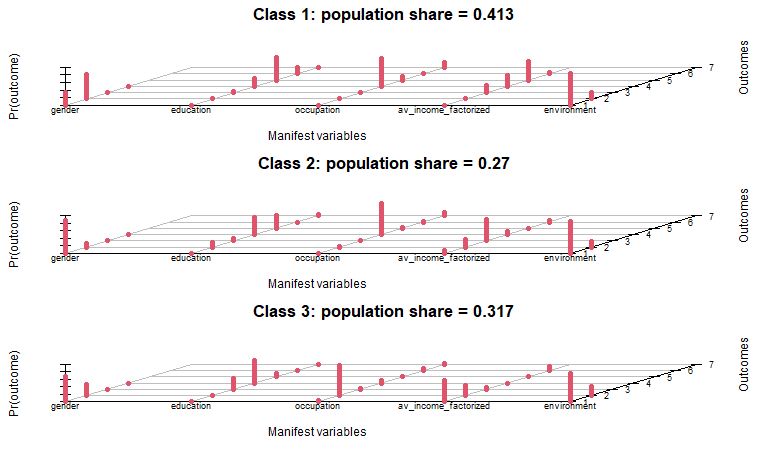

```r
plot(lca_1)
```

```r
# optimize number of classes based on AIC, BIC an max log likelihood
```

```r
# library(kohonen)
#
#
# # apparently not good for mixed data
# data_cluster_scaled <- scale(data_cluster)
#
# som_grid_1 <- somgrid(xdim = 5, ydim = 5, topo = "hexagonal")
#
# som_model_1 <- som(data_cluster_scaled, grid = som_grid_1)
#
# plot(som_model_1, type = "codes")
#
# plot(som_model_1, type = "mapping")
```

```r
# nice way of showing relationships of variables
# plot(hclust(dist(abs(cor(na.omit(data_cluster))))))
#
# print(cor(na.omit(data_cluster)))
# print(dist(abs(cor(na.omit(data_cluster)))))
#
#
# # correlation matrix for categorical data does not make sense does it?
# # would it work if it's binarized?
# # the data does not have to be normalized, right?
#
```

# let’s do this one a little later

[figure not shown]

```r
print(chi_squared_1$p_matrix)
```

```
                             [,1]         [,2]         [,3]         [,4]         [,5]      [,6]
gender                         NA 6.270507e-18 8.203608e-04 8.465631e-01 3.531076e-12 0.1881468
Country_Name         6.270507e-18           NA 3.194535e-04 7.232509e-06 1.869863e-04 0.2955951
education            8.203608e-04 3.194535e-04           NA 4.096051e-25 1.017458e-30 0.6547902
occupation           8.465631e-01 7.232509e-06 4.096051e-25           NA 1.315626e-52 0.3905500
av_income_factorized 3.531076e-12 1.869863e-04 1.017458e-30 1.315626e-52           NA 0.1242768
environment          1.881468e-01 2.955951e-01 6.547902e-01 3.905500e-01 1.242768e-01        NA
```

[figure not shown]

```r
# check how similar participants are
```

```r
# transform data to long format
data_lf <- data_recoded %>% gather(GB_S1, GB_S2, GB_S3, GB_S4, GB_S5, GB_S6,
                                 GB_S7, GB_S8, GB_S9, PA_S1, PA_S2, PA_S3,
                                 PA_S4, PA_S5, PA_S6, PA_S7, PA_S8, PA_S9,
                                 CHO_S1, CHO_S2, CHO_S3, CHO_S4, CHO_S5,
                                 CHO_S6, CHO_S7, CHO_S8, CHO_S9,
                                 key = "choice", value = "decision")


# check results
print(paste0("Expected number of rows: ",
             length(unique(data_recoded$lfdn)) * (3*9)))
```

```
[1] "Expected number of rows: 14634"
```

```r
print(paste0("Actual number of rows: ", nrow(data_lf)))
```

```
[1] "Actual number of rows: 14634"
```

```r
# recode decision-variable to 0-1
data_lf$decision <- ifelse(data_lf$decision == 2, 1, 0)


# factorize variables that should be factorized but are not factorized yet
data_lf$decision <- as.factor(data_lf$decision)
data_lf$country <- as.factor(data_lf$country)
print_empty_line()
```

```r
print("Datatypes:")
```

```
[1] "Datatypes:"
```

```r
print(sapply(data_lf, class))
```

```
$lfdn
[1] "numeric"

$purchase_CHO
[1] "numeric"

$purchase_PA
[1] "numeric"

$purchase_GB
[1] "numeric"

$rank_GB
[1] "numeric"

$rank_CHO
[1] "numeric"

$rank_CHEESE
[1] "numeric"

$rank_WHEAT
[1] "numeric"

$rank_TOM
[1] "numeric"

$age
[1] "numeric"

$gender
[1] "factor"

$country
[1] "factor"

$education
[1] "factor"

$occupation
```

[output cut: 40 more lines]

```

$Completion_Time
[1] "character"

$Completion_Time_sec
[1] "numeric"

$av_income_factorized
[1] "factor"

$choice
[1] "character"

$decision
[1] "factor"
```

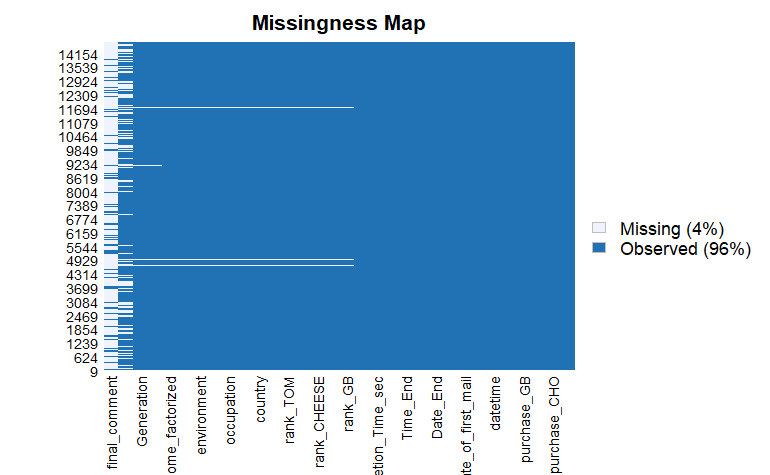

```r
library(Amelia)
# visualize frequency of missing values
missmap(data_lf)
```

```r
# function to get NA's of a dataframe for each variable
na_perc <- function(dataset){
  na_s <- data.frame(colnames(dataset))
  na_s["NA_freq"] <- rep(NA, dim(dataset)[2])
  for (i in 1:dim(dataset)[2]){
    na_s[i, 2] <- round(sum(is.na(dataset[,i])) / dim(dataset)[1], 4) * 100
  }
  na_s <- na_s[order(na_s$NA_freq, decreasing = TRUE),]
  colnames(na_s) <- c("variable", "na_percantage")
  return(na_s)
}
```

```r
# na-frequencies long-format dataset
na_perc(data_lf)
```

|  | variable | na_percantage |
| --- | --- | --- |
| 19 | final_comment | 82.84 |
| 32 | decision | 26.07 |
| 10 | age | 0.92 |
| 18 | Generation | 0.92 |
| 5 | rank_GB | 0.74 |
| 6 | rank_CHO | 0.74 |
| 7 | rank_CHEESE | 0.74 |
| 8 | rank_WHEAT | 0.74 |
| 9 | rank_TOM | 0.74 |
| 11 | gender | 0.74 |

[output cut: 22 more lines]

```r
NA
```

final_comment has a lot of NA’s as expected, which is fine in this case, as the variable will not be used for the model comparison. decision also has a lot of NA’s which is not surprising as it includes all decision that were by construction not made by certain participants (e.g. someone expressing that they do not buy chocolate will have automatically NA’s for all choices regarding chocolate). In this case the best way to deal with these NA’s is to throw them out either way, as they were no meant to be observations in the first place. Imputation is not a good strategy here, as someone who does no buy chocolate could be very different from individuals who do, hence, using information from other individuals for an educated guess might be biased. Other variables have little amoutn of NA’s.

```r
# naive estimate of how many of NA's overall could be traced back to decision
print(paste0("NA percantage for decision: ",
            na_perc(data_lf %>% subset(select = decision))[2], "%"))
```

```
[1] "NA percantage for decision: 26.07%"
```

```r
print(paste0("NA percantage in any row: ",
             round(sum(!complete.cases(data_lf %>%
                                         subset(select = -c(final_comment)))) /
                     nrow(data_lf) * 100, 2), "%"))
```

```
[1] "NA percantage in any row: 26.19%"
```

```r
# number of rows before removing NA's
print(paste0("number of rows before cleaning: ", nrow(data_lf)))
```

```
[1] "number of rows before cleaning: 14634"
```

```r
data_lf <- data_lf %>% subset(select = -c(final_comment))
data_lf_test <- data_lf %>% subset(!is.na(decision))
print(paste0("number of rows, when only deleting rows that have NA's for the
choice variable: ", nrow(data_lf_test)))
```

```
[1] "number of rows, when only deleting rows that have NA's for the \nchoice variable: 10819"
```

```r
data_lf <- data_lf[complete.cases(data_lf),]
print(paste0("number of rows, after cleaning: ", nrow(data_lf)))
```

```
[1] "number of rows, after cleaning: 10801"
```

```r
na_perc(data_lf)
```

|  | variable | na_percantage |
| --- | --- | --- |
| 1 | lfdn | 0 |
| 2 | purchase_CHO | 0 |
| 3 | purchase_PA | 0 |
| 4 | purchase_GB | 0 |
| 5 | rank_GB | 0 |
| 6 | rank_CHO | 0 |
| 7 | rank_CHEESE | 0 |
| 8 | rank_WHEAT | 0 |
| 9 | rank_TOM | 0 |
| 10 | age | 0 |

[output cut: 21 more lines]

```r
NA
NA
```

Only 18 rows have NA’s left when deleting the rows that have NA’s for the decision variable, hence these rows will also be removed in this case.

```r
# create new variables for price
data_lf$price_cn <- rep(0, nrow(data_lf))
data_lf$price_no_cn <- rep(0, nrow(data_lf))
data_lf$product_type <- rep(0, nrow(data_lf))


# # maybe a function for later
# map_prices <- function(dataframe, variable, price_list, price_variable,
#                        choice_variable){
#   dataframe[price_variable][dataframe$choice_variable %>% contains("_S1")
#                             | contains("_S4") | contains("_S5")]
# }


# add prices
# ground beef carbon neutral
data_lf$price_cn <- ifelse(data_lf$choice %in%
                             c("GB_S1", "GB_S4", "GB_S5"),
                           3.49,
                           ifelse(data_lf$choice %in%
                                    c("GB_S2", "GB_S6", "GB_S8"),
                                  4.99,
                                  ifelse(data_lf$choice %in%
                                           c("GB_S3", "GB_S7", "GB_S9"),
                                         6.59,
                                         data_lf$price_cn)))
# pasta carbon neutral
data_lf$price_cn <- ifelse(data_lf$choice %in%
                             c("PA_S1", "PA_S4", "PA_S5"),
                           1.09,
                           ifelse(data_lf$choice %in%
                                    c("PA_S2", "PA_S6", "PA_S8"),
                                  1.79,
                                  ifelse(data_lf$choice %in%
                                           c("PA_S3", "PA_S7", "PA_S9"),
                                         2.49,
                                         data_lf$price_cn)))
# chocolate carbon neutral
data_lf$price_cn <- ifelse(data_lf$choice %in%
                             c("CHO_S1", "CHO_S4", "CHO_S5"),
                           0.79,
                           ifelse(data_lf$choice %in%
                                    c("CHO_S2", "CHO_S6", "CHO_S8"), 1.29,
                                  ifelse(data_lf$choice %in%
                                           c("CHO_S3", "CHO_S7", "CHO_S9"),
                                             1.79,
                                             data_lf$price_cn)))

# ground beef not carbon neutral
data_lf$price_no_cn <- ifelse(data_lf$choice %in%
                                c("GB_S1", "GB_S2", "GB_S3"),
                              3.49,
                              ifelse(data_lf$choice %in%
                                       c("GB_S4", "GB_S6", "GB_S7"),
                                     4.99,
                                     ifelse(data_lf$choice %in%
                                              c("GB_S5", "GB_S8", "GB_S9"),
                                                6.59,
                                                data_lf$price_no_cn)))
# pasta not carbon neutral
data_lf$price_no_cn <- ifelse(data_lf$choice %in%
                                c("PA_S1", "PA_S2", "PA_S3"),
                              1.09,
                              ifelse(data_lf$choice %in%
                                       c("PA_S4", "PA_S6", "PA_S7"),
                                     1.79,
                                     ifelse(data_lf$choice %in%
                                              c("PA_S5", "PA_S8", "PA_S9"),
                                            2.49,
                                            data_lf$price_no_cn)))
# chocolate not carbon_neutral
data_lf$price_no_cn <- ifelse(data_lf$choice %in%
                                c("CHO_S1", "CHO_S2", "CHO_S3"),
                              0.79,
                              ifelse(data_lf$choice %in%
                                       c("CHO_S4", "CHO_S6", "CHO_S7"),
                                     1.29,
                                     ifelse(data_lf$choice %in%
                                              c("CHO_S5", "CHO_S8", "CHO_S9"),
                                                1.79,
                                                data_lf$price_no_cn)))


# add product category
library(stringr)
data_lf$product_type <- ifelse(data_lf$choice %>%
                                 str_detect("GB") == TRUE,
                               "Ground beef",
                               ifelse(data_lf$choice %>%
                                        str_detect("PA") == TRUE,
                                      "Pasta", "Chocolate"))
```

```r
# check outcome-distribution
print("outcome distribution:")
```

```
[1] "outcome distribution:"
```

```r
print(table(data_lf$decision, useNA = "always"))
```

```
   0    1 <NA>
2599 8202    0
```

```r
print_empty_line()
```

```r
# remove observations with outcome "neither" since there are few observations
# and multinomial logistic regression with random effects is not reliably
# available in R
print(paste0("number of observations before removing 'neither': ",
             dim(data_lf)))
```

```
[1] "number of observations before removing 'neither': 10801"
[2] "number of observations before removing 'neither': 34"
```

```r
data_model <- data_lf[data_lf$decision != 3,]
print(paste0("number of observations after removing 'neither': ",
             dim(data_model)))
```

```
[1] "number of observations after removing 'neither': 10801"
[2] "number of observations after removing 'neither': 34"
```

```r
# check that every combination of outcome and expression of regressors is in
# the data
var_list <- c("gender", "education", "occupation", "av_income_factorized",
              "price_cn", "price_no_cn", "product_type", "environment",
              "country", "age")

for (variable in var_list){
  formula_temp <- paste0("~ decision + ", variable)
  #print(formula_temp)
  print("variable: ")
  print(xtabs(formula_temp, data = data_model))
  print_empty_line()
}
```

```
[1] "variable: "
        gender
decision Female Male Non-binary Other
       0   1482 1097         11     9
       1   4891 3250         43    18

[1] "variable: "
        education
decision Secondary School General Secondary School Secondary School Academic Bachelor's Degree Master's Degree
       0                        3              131                       291              1030             930
       1                       24              274                       897              3282            3084
        education
decision Ph.D. or higher None
       0             171   43
       1             621   20

[1] "variable: "
        occupation
decision Student Highschool Student University In education or vocational training Employed Retired
       0                 29                752                                  31     1436      90
       1                 70               1975                                 131     4721     396
        occupation
decision Looking for employment Other
       0                     73   188
       1                    188   721

[1] "variable: "
        av_income_factorized
decision <1000 1000-1500 1500-3500 3500-5000 >5000 No answer
       0   543       374       649       347   495       191
       1  1500      1120      1943      1157  1917       565

[1] "variable: "
        price_cn
decision 0.79 1.09 1.29 1.79 2.49 3.49 4.99 6.59
       0   98   98  246  759  703   99  170  426
       1 1118 1315  969 1869  710  873  802  546

[1] "variable: "
        price_no_cn
```

[output cut: 20 more lines]

```
       1   58    4   19 3724    0   12 3773   18  106   53    6    8   32  112   43   51  171   12

[1] "variable: "
        age
decision  17  18  19  20  21  22  23  24  25  26  27  28  29  30  31  32  33  34  35  36  37  38  39  40  41  42
       0   9  49   2  29  80  53  67 148 336 244 100 100  66  34  15  11   6  12  31   7  34  16  11   5   7  11
       1  18 113  16 124 190 118 194 428 888 773 269 332 276 110  57  79  21  42 122  29  47  38  34  22  29  52
        age
decision  43  44  45  46  47  48  49  50  51  52  53  54  55  56  57  58  59  60  61  62  63  64  65  66  67  68
       0  40  16  39  22  31  42  57  44   7  95  49  78 135  44  40  38  26  92  38  27  33  21   9   3   9  11
       1 113  47  78 131  59  84 114 136  20 220 167 255 351 190 221 223 235 412 178  90  49  69  45  33  27  43
        age
decision  69  70  71  72  73  74  77  78  81  82  83  84
       0   5   0   9  16   9   8   5   1  17   0   0   0
       1   4  18  45  11  45   1   4   8  19  18   9   9
```

```r
# most regressors are fine but some expressions of the country-variable are
# have one-sided outcomes, some models (e.g. logistic regression) will not
# be able to estimate probabilities for these variable-expressions
# age also does also have one-sided distributions for some ages, this should
# be fine however, since age is continuous


# write function to get expressions with one-sided outcome-distributions
target_acquired <- function(dataset, variable){
  expression_list = c()
  formula_temp <- paste0("~decision + ", variable)
  xtab_temp <- xtabs(formula_temp, data = dataset)
  colnames_temp <- colnames(xtab_temp)
  for (name in colnames_temp){
    expression_temp <- xtab_temp[, name]
    if (0 %in% expression_temp){
      expression_list = c(expression_list, name)
    }
  }
  return(expression_list)
}

# countries
countries_one_sided <- target_acquired(data_model, "country")
print(countries_one_sided)
```

```
[1] "56"
```

```r
# ages
ages_one_sided <- target_acquired(data_model, "age")
print(ages_one_sided)
```

```
[1] "70" "82" "83" "84"
```

```r
# subset data based on retrieved expressions
print(dim(data_model))
```

```
[1] 10801    34
```

```r
data_model <- data_model %>% subset(!(country %in% countries_one_sided))
print(dim(data_model))
```

```
[1] 10774    34
```

```r
# check result
nrow(data_lf) == (nrow(data_model) +
                    nrow(data_lf[data_lf$country %in% countries_one_sided,]))
```

```
[1] TRUE
```

```r
# worked

# let's also remove ages with one-sided outcome-distributions just to be sure
data_model <- data_model %>% subset(!(age %in% ages_one_sided))
print(dim(data_model))
```

```
[1] 10720    34
```

```r
nrow(data_lf) == (nrow(data_model) +
                    nrow(data_lf[data_lf$country %in% countries_one_sided,]) +
                    nrow(data_lf[data_lf$age %in% ages_one_sided,]))
```

```
[1] TRUE
```

```r
# worked
```

```r
# check how variables are coded (which categories are reference categories)
# helper-function
factor_check <- function(dataset){
  data_temp <- dataset[, sapply(dataset, is.factor)]
  return(data_temp)
}


check_coding <- function(dataset, variable_list){
  data_temp <- dataset[, variable_list]
  data_temp <- factor_check(data_temp)

  for(var in colnames(data_temp)){
    print(paste0(var, ":"))
    print(contrasts(data_temp[, var][[1]]))
    print_empty_line()
  }
}

print("Coding of variables: ")
```

```
[1] "Coding of variables: "
```

```r
check_coding(data_model, var_list)
```

```
[1] "gender:"
           Male Non-binary Other
Female        0          0     0
Male          1          0     0
Non-binary    0          1     0
Other         0          0     1

[1] "education:"
                          Secondary School Secondary School Academic Bachelor's Degree Master's Degree
Secondary School General                 0                         0                 0               0
Secondary School                         1                         0                 0               0
Secondary School Academic                0                         1                 0               0
Bachelor's Degree                        0                         0                 1               0
Master's Degree                          0                         0                 0               1
Ph.D. or higher                          0                         0                 0               0
None                                     0                         0                 0               0
                          Ph.D. or higher None
Secondary School General                0    0
Secondary School                        0    0
Secondary School Academic               0    0
Bachelor's Degree                       0    0
Master's Degree                         0    0
Ph.D. or higher                         1    0
None                                    0    1

[1] "occupation:"
                                    Student University In education or vocational training Employed Retired
Student Highschool                                   0                                   0        0       0
Student University                                   1                                   0        0       0
In education or vocational training                  0                                   1        0       0
Employed                                             0                                   0        1       0
Retired                                              0                                   0        0       1
Looking for employment                               0                                   0        0       0
Other                                                0                                   0        0       0
                                    Looking for employment Other
Student Highschool                                       0     0
Student University                                       0     0
In education or vocational training                      0     0
Employed                                                 0     0
Retired                                                  0     0
```

[output cut: 22 more lines]

```
46   0  0  1  0  0  0  0  0   0   0   0   0   0   0   0   0   0
56   0  0  0  1  0  0  0  0   0   0   0   0   0   0   0   0   0
66   0  0  0  0  1  0  0  0   0   0   0   0   0   0   0   0   0
70   0  0  0  0  0  1  0  0   0   0   0   0   0   0   0   0   0
86   0  0  0  0  0  0  1  0   0   0   0   0   0   0   0   0   0
88   0  0  0  0  0  0  0  1   0   0   0   0   0   0   0   0   0
118  0  0  0  0  0  0  0  0   1   0   0   0   0   0   0   0   0
132  0  0  0  0  0  0  0  0   0   1   0   0   0   0   0   0   0
136  0  0  0  0  0  0  0  0   0   0   1   0   0   0   0   0   0
140  0  0  0  0  0  0  0  0   0   0   0   1   0   0   0   0   0
169  0  0  0  0  0  0  0  0   0   0   0   0   1   0   0   0   0
174  0  0  0  0  0  0  0  0   0   0   0   0   0   1   0   0   0
190  0  0  0  0  0  0  0  0   0   0   0   0   0   0   1   0   0
191  0  0  0  0  0  0  0  0   0   0   0   0   0   0   0   1   0
195  0  0  0  0  0  0  0  0   0   0   0   0   0   0   0   0   1
```

```r
# all factor-variables are properly dummy-coded
```

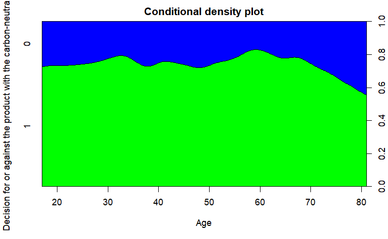

```r
# plotting distribution of outcomes over age
cdplot(decision ~ age,
       data = data_model,
       col = c("green", "blue"),
       ylab = "Decision for or against the product with the carbon-neutral label",
       xlab = "Age",
       main = "Conditional density plot")
```

```r
# outcome-distributions seems approximately equal over age
```

```r
# normalize numeric variables
library(caret)
# function that standardizes columns of a dataet based on a subset of variables
# given by a list
standardize_data <- function(dataset, variable_list){
  var_list_temp <- variable_list
  numeric_cols_temp <- dataset[, var_list_temp] %>%
    select_if(is.numeric) %>% colnames()
  print("Standardized variables:")
  print(numeric_cols_temp)
  #dataset_num_temp <- dataset[, numeric_cols_temp]
  #min_max_scaler <- preProcess(dataset_num_temp, method = "range")
  #dataset[, numeric_cols_temp] <- predict(min_max_scaler,
  #                                       dataset[, numeric_cols_temp])
  dataset[, numeric_cols_temp] <- scale(dataset[, numeric_cols_temp])
  return(dataset)
}

data_standardized <- standardize_data(data_model, var_list)
```

```
[1] "Standardized variables:"
[1] "price_cn"    "price_no_cn" "age"
```

```r
# subset dataframe for variables that are relevant for further analyses
data_model <- data_model %>% subset(select = c(lfdn, purchase_CHO, purchase_PA,
                                               purchase_GB, rank_GB, rank_CHO,
                                               rank_CHEESE, rank_WHEAT,
                                               rank_TOM, age, gender, country,
                                               education, occupation, av_income,
                                               environment, Country_Name,
                                               Generation, av_income_factorized,
                                               choice, decision, price_cn,
                                               price_no_cn, product_type))


# split data into training and test set by including certain individuals in the
# test set only to get a better estimate of the generalization error
individuals <- unique(data_model$lfdn)

# determine fractions for train and test set, I decided to include about 15%
# of individuals in the test set
train_size <- floor(0.85 * length(individuals))
test_size <- (length(individuals) - train_size)

# sample individuals for training and test set
# make sure the results can be repeated the same way
set.seed(100)

train_idx <- sample(individuals, train_size, replace = FALSE)
test_idx <- individuals[which(!individuals %in% train_idx)]

# test whether it worked correctly
count_dub = 0
for (i in train_idx){
  if (i %in% test_idx){
    count_dub = count_dub + 1
  }
}
print(paste0("number of dublicates: ", count_dub))
```

```
[1] "number of dublicates: 0"
```

```r
print(paste0("unique idx train set: ", length(unique(train_idx))))
```

```
[1] "unique idx train set: 452"
```

```r
print(paste0("unique idx test set: ", length(unique(test_idx))))
```

```
[1] "unique idx test set: 80"
```

```r
# worked

# split data into train and test set
train <- data_model[data_model$lfdn %in% train_idx, ]
test <- data_model[data_model$lfdn %in% test_idx, ]
# train might not contain exactly 85% of observations since the split was made
# based on individuals, hence, train has 85% of individuals, not necessary 85%
# of observations

# check if outcome distributions are approximately similar
print("outcome-distributions for training and test set (relative frequency:")
```

```
[1] "outcome-distributions for training and test set (relative frequency:"
```

```r
print(round(table(train$decision) / nrow(train), 2))
```

```
   0    1
0.23 0.77
```

```r
print(round(table(test$decision) / nrow(test), 2))
```

```
   0    1
0.27 0.73
```

```r
# distributions are similar


# # split data into train and test set based on observations overall
# sample_size <- floor(0.75 * nrow(data_model))
#
# set.seed(100)
# train_idx <- sample(seq(1, nrow(data_model), 1), size = sample_size)
#
# train_alter <- data_model[train_idx, ]
# test_alter <- data_model[-train_idx, ]



# check distribution of outcome-variable
print("Distribution of outcome variable in training set:")
```

```
[1] "Distribution of outcome variable in training set:"
```

```r
print(table(train$decision))
```

```
   0    1
2128 6936
```

```r
# create more balanced training sets
# option 1: upsample training set
library(caret)

# create dataframe with upsampled data
set.seed(100)  # next command samples
train_upsampled <- upSample(x = train %>% subset(select = -c(decision)),
                            y = as.factor(train$decision),
                            yname = "decision")

# check results
print("Distribution of outcome variable in upsampled training set:")
```

```
[1] "Distribution of outcome variable in upsampled training set:"
```

```r
table(train_upsampled$decision)
```

```
   0    1
6936 6936
```

```r
# option 2: downsample training set
set.seed(100)  # just to make sure
train_downsampled <- downSample(x = train %>% subset(select = -c(decision)),
                                y = as.factor(train$decision),
                                yname = "decision")

# check results
print("Distribution of outcome variable in downsampled training set:")
```

```
[1] "Distribution of outcome variable in downsampled training set:"
```

```r
table(train_downsampled$decision)
```

```
   0    1
2128 2128
```

```r
# option 3: ROSE
library(ROSE)
# preparation for ROSE
train_2 <- train
train_2$choice <- as.factor(train_2$choice)
train_2$product_type <- as.factor(train_2$product_type)

set.seed(100)
train_rose <- ROSE(as.factor(decision) ~ lfdn + age + as.numeric(gender) +
                     as.numeric(country) + as.numeric(education) +
                     as.numeric(occupation) + as.numeric(environment) +
                     as.numeric(av_income_factorized) + as.numeric(choice) +
                     price_cn + price_no_cn + as.numeric(product_type),
                   data = train_2)$data
# variables only transformed in the formula for the computation, hence the
# resulting dataframe keeps the assigned labels
# despite the name, no roses were trained in the process
print("Distribution of outcome variable in ROSE training set:")
```

```
[1] "Distribution of outcome variable in ROSE training set:"
```

```r
table(train_rose$decision)
```

```
   1    0
4549 4515
```

```r
# ROSE generates observations based on neighbours by using a smoothed
# bootstrapping approach, it selects an observation of one of the classes and
# generates new examples in its neighbourhood
# kernel-methods usually only work with continous data, but ROSE also works
# with non-continous data, since it uses over- and undersampling
# (e.g. a synthetic clone of x_i will have the same component for the j-th
# variable as x_i)


# option 4: SMOTE
# SMOTE only works with continuous data and is hence not applicable here





# # export data
# # does not need to be repeated every time the script runs
# write.csv(data_model, "data/data_model.csv")
# # export train and test sets
# write.csv(train, "data/train_model.csv")
# write.csv(test, "data/test_model.csv")
# write.csv(train_upsampled, "data/train_model_upsampled.csv")
# write.csv(train_downsampled, "data/train_model_downsampled.csv")
# write.csv(train_rose, "data/train_model_rose.csv")
```

```r
data_model_cor <- cor(data_model)
```

```
Error in cor(data_model) : 'x' muss numerisch sein
```

```r
# assumption 1: binary outcome variable
print("Assumption 1:")
print(unique(train$decision))
# outcome-variable was binarized before, this serves as sanity check
print_empty_line()



# assumption 2: little multicolinearity between regressors
library(car)

print("Assumption 2:")
print(car::vif(fit_1))
print_empty_line()
# (full rank assumption)




# assumption 3: linear relationship of log odds to independet variables
library(ggplot2)
library(sjPlot)


# plot_model(fit_1, type = "pred", terms = c("gender", "education", "occupation", "av_income_factorized", "price_cn", "price_no_cn", "product_type", "environment", "country"))
plot_model(fit_1)
# not sure whether this depcits what im trying to find out here
print_empty_line()




# assumption 4: sufficient sample size
print("Assumption 4:")
print(paste0("recommended minimum of observations: ", 100 + length(var_list) * 50))
print(paste0("number of observations: ", nrow(train)))
print_empty_line()




# assumption 5: no extreme outliers
library(car)

print("Assumption 5:")
print(cooks.distance(fit_1))
plot(cooks.distance(fit_1))
# not sure whether this predicts what im trying to find out
print_empty_line()





# assumption 6: independence of observations
print("Assumption 6:")
print("Dependence between observations, because of panel data structure, combatted by including random effects in the model.")







# additional random effects assumptions
# assumption 7-1: strict exogeneity of regressors and idiosyncratic errors




# assumption 7-2: strict exogeneity of regressors and individual-specific effects








# assumption 8-1: variance of idiosyncratic errors does not depend on the actual expression of the regressors







# assumption 8-2: variance of individual-specific effects does not depend on the actual expression of the regressors
```

```r
# linearity
# for every numeric regressor?
train %>%
  mutate(comp_res = fixef(fit_1)["age"] * age + residuals(fit_1, type = "working")) %>%
  ggplot(aes(x = age, y = comp_res)) +
  geom_point() +
  geom_smooth(color = "violetred", method = "lm", linetype = 2, se = FALSE) +
  geom_smooth(se = FALSE) +
  theme_bw()
# check again
# if non-linear realtionship adding the variable squared might help
# maybe add age^2



# Independence






# no multicollinearity
# VIFs







# no outlier effects
# DFFITS
train_dffits <- train %>%
  mutate(dffits = dffits(fit_1))

train_dffits %>%
  mutate(obs_number = row_number(),
         large = ifelse(abs(dffits) > 2 * sqrt(length(coef(fit_1)) / nobs(fit_1)),
                        "red", "black")) %>%
  ggplot(aes(obs_number, dffits, color = large)) +
  geom_point() +
  geom_hline(yintercept = c(-1, 1) * 2 * sqrt(length(coef(fit_1)) / nobs(fit_1)), color = "red") +
  scale_color_identity() +
  theme_bw()



# DFBETAS
train_dfbetas <- dfbetas(fit_1) %>%
  as.data.frame() %>%
  rename_with(~ paste0("dfb_", .x)) %>%
  cbind(train)

train_dfbetas %>%
  mutate(obs_number = row_number()) %>%
  pivot_longer(cols = starts_with("dfb")) %>%
  mutate(large = ifelse(abs(value) > 2 / sqrt(nobs(fit_1)),
                        "red", "black")) %>%
  ggplot(aes(obs_number, value, color = large)) +
  geom_point() +
  geom_hline(yintercept = c(-1, 1) * 2 / sqrt(nobs(fit_1)), color = "red") +
  facet_wrap(~ name) +
  scale_color_identity() +
  theme_bw()






# fully represented data matrix
# contingency tables
# multiple way contingency-cells
# e.g.
with(train, table(gender, education, occupation))
# if empty cells: collapse categories, or drop variables (collecting more data not feasible in this case)
```

```r
# examine choice-variables
#table(data_choc$CHO_S1, useNA = "always")

# function to table all variables of a dataset
table_values <- function(dataset){
  for (i in 1:dim(dataset)[2]){
    #print(colnames(dataset[,i]))
    print(table(dataset[,i], useNA = "always"))
    print_empty_line()
  }
}


# check choice-variables
# choice-distribution chocolate
table_values(data_choc %>% select(matches("_S[[:digit:]]+")))
```

```r
# choice-distribution pasta
table_values(data_pasta %>% select(matches("_S[[:digit:]]+")))
```

```r
# choice-distribution ground beef
table_values(data_grouf %>% select(matches("_S[[:digit:]]+")))
```

```r
# recode choice-variables so for every variable the second option is the one
# with the carbon neutral label
recode_vars <- function(dataset_choice, variables){
  dataset_choice <- dataset_choice %>%
    mutate_at(variables, funs(recode(., '1' = 2, '2' = 1, '3' = 3,
                                     .default = NaN)))
  return(dataset_choice)
}



# check distribution of one variable for comparison
print("CHO_S3 before recoding:")
print(table(data_choc$CHO_S3))
print("")



# recode dataset for chocolate
data_choc <- recode_vars(data_choc, c("CHO_S3", "CHO_S5", "CHO_S7", "CHO_S8",
                                      "CHO_S9"))

# recode dataset for pasta
data_pasta <- recode_vars(data_pasta, c("PA_S3", "PA_S5", "PA_S7", "PA_S8",
                                        "PA_S9"))

# recode dataset for groundbeef
data_grouf <- recode_vars(data_grouf, c("GB_S3", "GB_S5", "GB_S7", "GB_S8",
                                        "GB_S9"))



# check distribution for one variable after recoding
print("CHO_S3 after recoding:")
print(table(data_choc$CHO_S3))




# build variable indicating environmental consciousness
# environmental consciousness indicator does not work well, might look at it
# again later
build_env_cons_var <- function(dataset, product){
  # create column for result
  dataset["environmental_consciousness_indicator"] <- rep(NA, dim(dataset)[1])
  # subset data for relevant variables
  dataset_choice <- dataset %>% select(matches(paste0(product,
                                                      "_S[[:digit:]]+")))

  # subset dataset for categories of choices
  dataset_choice_same_price <- dataset_choice %>% select(matches(paste0(product,
                                                      "_S[1, 6, 9]")))
  dataset_choice_cn_more_expensive <- dataset_choice %>%
    select(matches(paste0(product, "_S[2, 7]")))

  dataset_choice_cn_more_expensive_extreme <- dataset_choice %>%
    select(matches(paste0(product, "_S[3]")))

  dataset_choice_cn_less_expensive <- dataset_choice %>%
    select(matches(paste0(product, "_S[4, 8]")))

  dataset_choice_cn_less_expensive_extreme <- dataset_choice %>%
    select(matches(paste0(product, "_S[5]")))


  # # check
  # print("data subsets:")
  # print(product)
  # print(colnames(dataset_choice_same_price))
  # print(colnames(dataset_choice_cn_more_expensive))
  # print(colnames(dataset_choice_cn_more_expensive_extreme))
  # print(colnames(dataset_choice_cn_less_expensive))
  # print(colnames(dataset_choice_cn_less_expensive_extreme))
  # print("")




  # recode variables to match the score the particular answer gives

  # print(paste0("same price before ", product, ":"))
  # print(lapply(dataset_choice_same_price, table))


  cols_same_price <- colnames(dataset_choice_same_price)
  dataset_choice_same_price <- dataset_choice_same_price %>%
    mutate_at(cols_same_price, funs(recode(., '1' = -1, '2' = 1, '3' = 0,
                                           .default = NaN)))

  # print(paste0("same price after ", product, ":"))
  # print(lapply(dataset_choice_same_price, table))
  #
  #
  #
  # print(paste0("cn more expensive before ", product, ":"))
  # print(lapply(dataset_choice_cn_more_expensive, table))



  cols_cn_more_expensive <- colnames(dataset_choice_cn_more_expensive)
  dataset_choice_cn_more_expensive <- dataset_choice_cn_more_expensive %>%
    mutate_at(cols_cn_more_expensive, funs(recode(., '1' = 0, '2' = 2,
                                                  '3' = 0, .default = NaN)))



  # print(paste0("cn more expensive after ", product, ":"))
  # print(lapply(dataset_choice_cn_more_expensive, table))
  #
  #
  # print(paste0("cn more expensive extreme before ", product, ":"))
  # print(lapply(dataset_choice_cn_more_expensive_extreme, table))



  cols_cn_more_expensive_extreme <-
    colnames(dataset_choice_cn_more_expensive_extreme)
  dataset_choice_cn_more_expensive_extreme <-
    dataset_choice_cn_more_expensive_extreme %>%
    mutate_at(cols_cn_more_expensive_extreme, funs(recode(., '1' = 0, '2' = 3,
                                                          '3' = 0,
                                                          .default = NaN)))


  # print(paste0("cn more expensive extreme after ", product, ":"))
  # print(lapply(dataset_choice_cn_more_expensive_extreme, table))
  #
  #
  # print(paste0("cn less expensive before ", product, ":"))
  # print(lapply(dataset_choice_cn_less_expensive, table))



  cols_cn_less_expensive <- colnames(dataset_choice_cn_less_expensive)
  dataset_choice_cn_less_expensive <- dataset_choice_cn_less_expensive %>%
    mutate_at(cols_cn_less_expensive, funs(recode(., '1' = -2, '2' = 0,
                                                  '3' = 0, .default = NaN)))


  # print(paste0("cn less expensive after ", product, ":"))
  # print(lapply(dataset_choice_cn_less_expensive, table))
  #
  #
  # print(paste0("cn less expensive extreme before ", product, ":"))
  # print(lapply(dataset_choice_cn_less_expensive_extreme, table))


  cols_cn_less_expensive_extreme <-
    colnames(dataset_choice_cn_less_expensive_extreme)
  dataset_choice_cn_less_expensive_extreme <-
    dataset_choice_cn_less_expensive_extreme %>%
    mutate_at(cols_cn_less_expensive_extreme, funs(recode(., '1' = -3, '2' = 0,
                                                   '3' = 0, .default = NaN)))


  # print(paste0("cn less expensive extreme after ", product, ":"))
  # print(lapply(dataset_choice_cn_less_expensive_extreme, table))
  # print("")
  # print("=====================================================================")

  # calculate indicator
  dataset["environmental_consciousness_indicator"] =
    rowSums(dataset_choice_same_price, na.rm = TRUE) +
    rowSums(dataset_choice_cn_more_expensive, na.rm = TRUE) +
    rowSums(dataset_choice_cn_more_expensive_extreme, na.rm = TRUE) +
    rowSums(dataset_choice_cn_less_expensive, na.rm = TRUE) +
    rowSums(dataset_choice_cn_less_expensive_extreme, na.rm = TRUE)

  return(dataset)
}

# build indicator variable for chocolate dataset
data_choc <- build_env_cons_var(data_choc, "CHO")
data_pasta <- build_env_cons_var(data_pasta, "PA")
data_grouf <- build_env_cons_var(data_grouf, "GB")



# check functions again to make sure they make sense and work as intended
# and check whether the data encoding is correct
```

```r
# not needed for current approach of the analysis

# histograms of environmental consciousness indicator by dataset
# chocolate
hist(data_choc$environmental_consciousness_indicator, col = "cornflowerblue",
     main = "Environmental consciousness indicator distribution chocolate",
     xlim = c(-10, 10), xlab = "environmental consciousness indicator",
     ylab = "absolute frequency")

# pasta
hist(data_pasta$environmental_consciousness_indicator, col = "cornflowerblue",
     main = "Environmental consciousness indicator distribution pasta",
     xlim = c(-10, 10), xlab = "environmental consciousness indicator",
     ylab = "absolute frequency")

# groundbeef
hist(data_grouf$environmental_consciousness_indicator, col = "cornflowerblue",
     main = "Environmental consciousness indicator distribution ground beef",
     xlim = c(-10, 10), xlab = "environmental consciousness indicator",
     ylab = "absolute frequency")



# all conversions examined, given the system at hand, the distributions should
# be sound
```

```r
# automated approach within next code cell

# check whether similar choices were made

# answers already recoded to have the same direction (recode_vars-function)

# does factor analysis make sense for the type of data?

library(psych)
library(GPArotation)
library(nFactors)



# get an estimate of number of factors
evs_choc <- eigen(cor(na.omit(data_choc %>%
                                select(matches("_S[[:digit:]]+")))))
ap_choc <- parallel(subject=nrow(data_choc %>%
                                   select(matches("_S[[:digit:]]+"))),
                    var=ncol(data_choc %>% select(matches("_S[[:digit:]]+"))),
                    rep=100, cent=0.5)
nsr_choc <- nScree(x=evs_choc$values, apparallel=ap_choc$eigen$qevpea)
print(plotnScree(nsr_choc))

# 2-3 factors
choc_fa <- factanal(data_choc %>% select(matches("_S[[:digit:]]+")),
                    factors = 3)
print(choc_fa)
print(choc_fa$uniquenesses)


# using another method
library(psych)

print("")
print("=========================================")
choc_fa_2 <- fa(data_choc %>% select(matches("_S[[:digit:]]+")), nfactors = 3,
                scores = "regression", rotate = "oblimin")
print(choc_fa_2$loadings)
print("")
print("loadings:")
print(choc_fa_2$uniquenesses)


# visualize first two factors
plot(choc_fa_2$loadings[,1], choc_fa_2$loadings[,2],
     xlab= "1", ylab = "2", xlim = c(-1,1), ylim = c(-1,1), main = "chocolate")
text(choc_fa_2$loadings[,1] - 0.00, choc_fa_2$loadings[,2] + 0.20,
     colnames(data_choc %>% select(matches("_S[[:digit:]]+"))),
     col = "cornflowerblue")
abline(h = 0, v = 0)



# similar answers for questions with same price; as well as questions for CN
# more expensive; as well as question where CN less expensive





# pasta
# get an estimate of number of factors
evs_pasta <- eigen(cor(na.omit(data_pasta %>%
                                 select(matches("_S[[:digit:]]+")))))
ap_pasta <- parallel(subject=nrow(data_pasta %>%
                                    select(matches("_S[[:digit:]]+"))),
                     var=ncol(data_pasta %>% select(matches("_S[[:digit:]]+"))),
                     rep=100,cent=0.5)
nsr_pasta <- nScree(x=evs_pasta$values, apparallel=ap_pasta$eigen$qevpea)
print("")
print("======================================================================")
print("pasta:")
print(plotnScree(nsr_pasta))
pasta_fa_2 <- fa(data_pasta %>% select(matches("_S[[:digit:]]+")), nfactors = 2,
                scores = "regression", rotate = "oblimin")
print(pasta_fa_2$loadings)
print("")
print("loadings:")
print(pasta_fa_2$uniquenesses)


# visualize first two factors
plot(pasta_fa_2$loadings[,1], pasta_fa_2$loadings[,2],
     xlab= "1", ylab = "2", xlim = c(-1,1), ylim = c(-1,1), main = "pasta")
text(pasta_fa_2$loadings[,1] - 0.00, pasta_fa_2$loadings[,2] + 0.20,
     colnames(data_pasta %>% select(matches("_S[[:digit:]]+"))),
     col = "cornflowerblue")
abline(h = 0, v = 0)





# ground beef
evs_grouf <- eigen(cor(na.omit(data_grouf %>%
                                 select(matches("_S[[:digit:]]+")))))
ap_grouf <- parallel(subject=nrow(data_grouf %>%
                                    select(matches("_S[[:digit:]]+"))),
                     var=ncol(data_grouf %>% select(matches("_S[[:digit:]]+"))),
                     rep=100,cent=0.5)
nsr_grouf <- nScree(x=evs_grouf$values, apparallel=ap_grouf$eigen$qevpea)
print("")
print("======================================================================")
print("ground beef:")
print(plotnScree(nsr_grouf))
grouf_fa_2 <- fa(data_grouf %>% select(matches("_S[[:digit:]]+")), nfactors = 2,
                scores = "regression", rotate = "oblimin")
print(grouf_fa_2$loadings)
print("")
print("loadings:")
print(grouf_fa_2$uniquenesses)




# visualize first two factors
plot(grouf_fa_2$loadings[,1], grouf_fa_2$loadings[,2],
     xlab= "1", ylab = "2", xlim = c(-1,1), ylim = c(-1,1),
     main = "ground beef")
text(grouf_fa_2$loadings[,1] - 0.00, grouf_fa_2$loadings[,2] + 0.20,
     colnames(data_grouf %>% select(matches("_S[[:digit:]]+"))),
     col = "cornflowerblue")
abline(h = 0, v = 0)
```

```r
# function to conduct an exploratory factor analysis
get_factor_analysis_exploratory <- function(dataset, rotations){

  # subset data
  data_temp <- dataset %>% select(matches("_S[[:digit:]]+"))
  # choose number of factors
  evs_temp <- eigen(cor(na.omit(data_temp )))
  ap_temp <- parallel(subject = nrow(data_temp), var = ncol(data_temp),
                      rep = 100, cent = 0.5)
  nsr_temp <- nScree(x = evs_temp$values, apparallel = ap_temp$eigen$qevpea)

  # print the scree plot
  print(plotnScree(nsr_temp))


  # choose number of factors
  n_fact <- nsr_temp$Components$noc

  print(paste0("number of factors: ", n_fact))


  # factor analysis
  for (rotation in rotations){
    fa_temp <- fa(data_temp, nfactors = n_fact, scores = "regression",
                  rotate = rotation)

    # print results
    print(paste0(rotation, ":"))
    print("laodings:")
    print(fa_temp$loadings)
    print("uniquenesses:")
    print(fa_temp$uniquenesses)

    # visualize first two factors
    if (n_fact > 1){
      plot(fa_temp$loadings[,1], fa_temp$loadings[,2],
           xlab = "1", ylab = "2", xlim = c(-1, 1), ylim = c(-1, 1),
           main = paste0("first two factors ", rotation))
      text(fa_temp$loadings[,1] - 0.00, fa_temp$loadings[,2] + 0.20,
           colnames(data_temp), col = "cornflowerblue")
      abline(h = 0, v = 0)
    }
  }
}

# specify rotations
fa_rotations = list("none", "varimax", "promax", "oblimin")


# chocolate
get_factor_analysis_exploratory(data_choc, fa_rotations)


# pasta
get_factor_analysis_exploratory(data_pasta, fa_rotations)


# ground beef
get_factor_analysis_exploratory(data_grouf, fa_rotations)
```

# Cluster Analysis for real this time

```r
library(mltools)
library(data.table)



# let's create a lovely function
get_cluster_analysis_dendrogram <- function(dataset, variables, label_var){
  # subset dataset for relevant variables
  data_temp <- dataset[, variables]

  print(paste0("step 1: ", colnames(data_temp)))

  # one-hot-encode factor variables
  # select factor variables
  data_temp_dummy <- data_temp %>% select_if(is.factor)
  # one-hot-encode
  data_temp_dummy_one_hot <- one_hot(as.data.table(data_temp_dummy))
  # put numeric variables and one-hot-encoded dummy-variables together
  data_temp_one_hot <- cbind(data_temp %>% select_if(is.numeric),
                             data_temp_dummy_one_hot)


  print("step 2: ")
  print(data_temp_one_hot)

  # normalize data
  data_temp_one_hot_means <- apply(data_temp_one_hot, 2, mean, na.rm = TRUE)
  data_temp_one_hot_sds <- apply(data_temp_one_hot, 2, sd, na.rm = TRUE)
  data_temp_normalized <- scale(data_temp_one_hot,
                                center = data_temp_one_hot_means,
                                scale = data_temp_one_hot_sds)

  print("step 3: ")
  print(data_temp_normalized)

  # get rid of NA's (preferable to imputation in this case?)
  data_temp_normalized <- na.omit(data_temp_normalized)

  print("step 3.5: ")
  print(dim(data_temp_normalized))

  # calculate distances
  data_temp_distances <- dist(data_temp_normalized)

  print("step 4: ")
  print(sum(is.na(data_temp_distances)))

  # hierarchical clustering
  data_temp_clusters <- hclust(data_temp_distances)


  print("we're here!")

  # get visualizations
  plot(data_temp_clusters)
  #plot(data_temp_clusters, labels = dataset[label_variable],
  #     main = paste0("Cluster Analysis ", label_variable))
  #plot(data_temp_clusters, hang = -1, labels = data_set[label_variable],
  #     main = paste0("Cluster Analysis ", label_variable))


  # lets return this, it might come in handy later
  return(data_temp_normalized)

}


variables_cluster_analysis <- c("age", "gender",
                                "education", "occupation",
                                "av_income_factorized")
label_variable = "CHO_S1"

data_choc_normalized <-
  get_cluster_analysis_dendrogram(data_choc, variables_cluster_analysis,
                               label_variable)



# gotta check cluster analysis using dendograms in general again
```

```r
library(cluster)
# reproducibility
set.seed(100)

# kmeans
k_clusters <- kmeans(data_choc_normalized, 5)


ot_clusters <- data_choc_normalized
data_choc_dist_short_set <- dist(ot_clusters, method = "euclidean")
cluster_1 <- hclust(data_choc_dist_short_set, method = "complete")
pamv_short_set <- pam(data_choc_dist_short_set, 4 , diss = FALSE)
clusplot(pamv_short_set, shade = FALSE, labels = 2,
         col.clus = "cornflowerblue",
         col.p = "violetred", span = FALSE,
         main = "kmeans", cex = 1)



# perhaps need to aggregate data for a cluster analysis






# try another library
library(factoextra)



kmeans_2 <- kmeans(data_choc_normalized, centers = 5, nstart = 25)

#fviz_cluster(kmeans_2, data_choc, ggtheme = theme_bw())
# need to work on this command
```

```r
library(nnet)

data_choc$CHO_S2 <- as.factor(data_choc$CHO_S2)

data_choc$CHO_S2_labeled <- factor(data_choc$CHO_S2,
                                   levels = c(1, 2, 3),
                                   labels = c("no_label", "cn_label",
                                              "neither"))


data_choc$CHO_S2_labeled <- relevel(data_choc$CHO_S2_labeled, ref = "no_label")

mlm_1 <- multinom(CHO_S2_labeled ~ age + education + av_income,
                    data = data_choc)

summary(mlm_1)

z <- summary(mlm_1)$coefficients/summary(mlm_1)$standard.errors

p <- (1 - pnorm(abs(z), 0, 1)) * 2
p
```

```r
# relative risk
print(exp(coef(mlm_1)))
```

```r
print(head(pp <- fitted(mlm_1)))


df_educ <- data.frame(education = c("Secondary School General",
                                 "Secondary School",
                                 "Secondary School Academic",
                                 "Bachelor's Degree",
                                 "Master's Degree",
                                 "Ph.D. or higher",
                                 "None"),
                   age = mean(data_choc$age, na.rm = TRUE),
                   av_income = mean(data_choc$av_income, na.rm = TRUE))
#should probably use the categorized av_income and median instead of mean or something similar

mlm_1_predict <- predict(mlm_1, newdata = df_educ, "probs")
print(mlm_1_predict)





# check the continous variable age
df_age <- data.frame(education = rep(c("Secondary School General",
                                 "Secondary School",
                                 "Secondary School Academic",
                                 "Bachelor's Degree",
                                 "Master's Degree",
                                 "Ph.D. or higher",
                                 "None"), each = 85-17),
                     age = rep(c(17:84), 7),
                     av_income = mean(data_choc$av_income))

# predicted probabilities
pp_age <- cbind(df_age, predict(mlm_1, newdata = df_age, type = "probs", se = TRUE))

# mean probs within each level of educ
mean_probs <- by(pp_age[4:6], pp_age$education, colMeans)
print(mean_probs)
```

```r
library(reshape)

pp_age <- subset(pp_age, select = -c(av_income))

lpp <- melt(pp_age, id.vars = c("education", "age"))
print(head(lpp))




# plot
plot_prob_1 <- ggplot(lpp,
                      aes(x = age, y = value,
                          colour = education)) +
  geom_line() +
  facet_grid(variable ~ ., scales = "free") +
  theme_bw()
print(plot_prob_1)
```

```r
# regression analysis
reg_1 <- lm(environmental_consciousness_indicator ~ country + age + education + av_income + occupation + gender,
            data = data_choc)
print(summary(reg_1))



# try single choice-variables
data_choc_test <- data_choc %>% subset(CHO_S1 == 1 | CHO_S1 == 2)

reg_test <- glm(environmental_consciousness_indicator ~ as.factor(country) + age + education + occupation + gender, data = data_choc_test)

print(summary(reg_test))
```

```r
# also add a directed acylyic graph at some point... would be a lovely detail
library(randomForest)

X <- data_choc[,c("age", "education", "av_income", "occupation")]
Y <- data_choc$CHO_S2
X[is.na(X)] <- 0

forest_1 <- randomForest(X, Y)
summary(forest_1)

library(party)
cforest(CHO_S2 ~ country + age + education +
          av_income + occupation + gender, data = data_choc,
        controls=cforest_control(mtry=2, mincriterion=0))


getTree(forest_1)
```